# 案例學習二

## 隨時意識到自己在哪裡？

找一本讀得下去的書配合學習，發問。（e.g., http://yijutseng.github.io/DataScienceRBook/）

> 複習 `Base R` [第一張重要小抄](http://github.com/rstudio/cheatsheets/raw/master/base-r.pdf)
- 程式的結構
- 資料型態 Data type (string, number, date), 資料結構 Data structure (vector, matrix, data frame, list)
- Data frame 要特別花心思了解與熟悉。

> I/O
- RStudio 的懶人資料匯入法 (`Environment` - `Import Dataset`)
- 內建的 I/O 函數 `read.csv(),read.csv2(), read.table(),read.delim(), write.csv(), write.table().....`
- 利用 `readr` 套件 [第二張重要小抄](https://github.com/rstudio/cheatsheets/raw/master/data-import.pdf)

## 案例 A：玩不膩的鳶尾花

`iris` 各種檔案輸入練習。(G1 -> G2 -> ….-> G1)

## Data transformation/munging/wrangling (using `dplyr`)

- “載入資料之後，就進入資料整理（Data manipulation）或稱資料改寫（Data munging）、資料角力（Data wrangling）的部分。目的是為了方便探索、或者機器學習模型需求，必須將資料整理成合乎需求的格式。
- 到底什麼是 data manipulation?

> 進入資料探索分析 `Data Transformation` [第二張重要小抄](https://github.com/rstudio/cheatsheets/raw/master/data-transformation.pdf)

然後這張圖又出現了。

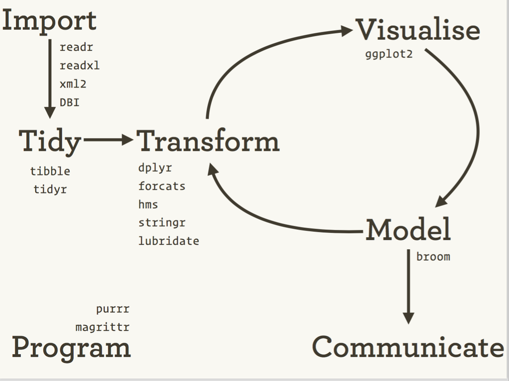

# Tidyverse： R 的簡約主義

[figure not shown]

https://www.tidyverse.org/

- 站在神人的肩膀上做資料科學。
- 核心想法：
  - 資料的簡約要求 (tidy data)。http://r4ds.had.co.nz/tidy-data.html
  - 在某些場合使用管線概念寫程式 (pipeline)；
  - 資料清整的新文法 (dplyr)
  - 資料做圖的新文法 (ggplot2)

```r
plot_important_things(
  summarize(
    remove_dodgy_data(
      read_data("/some/path/some_file.data"))))
```

- Writing pipelines of function calls

`x %>% f` 等於 `f(x)`, `x %>% f %>% g %>% h` 等於 `h(g(f(x)))`

```r
read_data("/some/path/some_file.data") %>%
  remove_dodgy_data %>%
  summarize %>%
  plot_important_things
```

- `dplyr`

## 案例 B：玩不膩的鳶尾花之二

|  | Sepal.Length | Sepal.Width | Petal.Length | Petal.Width | Species |
| --- | --- | --- | --- | --- | --- |
| 1 | 5.1 | 3.5 | 1.4 | 0.2 | setosa |
| 2 | 4.9 | 3.0 | 1.4 | 0.2 | setosa |
| 3 | 4.7 | 3.2 | 1.3 | 0.2 | setosa |
| 4 | 4.6 | 3.1 | 1.5 | 0.2 | setosa |
| 5 | 5.0 | 3.6 | 1.4 | 0.2 | setosa |

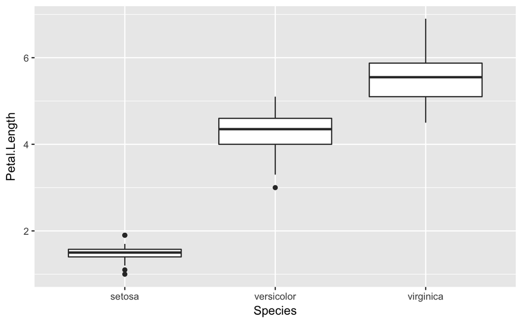

```r
iris %>%
  select(Species, Petal.Length) %>%
  qplot(Species, Petal.Length, geom = "boxplot", data = .)
```

## 案例 C：

- 團體練習：把程式與想法丟在 https://paper.dropbox.com/doc/Case-Study-Collaborative-Way-64YWTbYXKEviSqG8yppsc

A data frame with 58788 rows and 24 variables:

- title. Title of the movie.
- year. Year of release.
- budget. Total budget (if known) in US dollars
- length. Length in minutes.
- rating. Average IMDB user rating.
- votes. Number of IMDB users who rated this movie.
- r1-10. Multiplying by ten gives percentile (to nearest 10%) of users who rated this movie a 1.
- mpaa. MPAA rating.
- action, animation, comedy, drama, documentary, romance, short. Binary variables representing if movie was classified as belonging to that genre.

| title | year | length | budget | rating | votes | r1 | r2 | r3 | r4 | r5 | r6 | r7 | r8 | r9 | r10 | mpaa | Action | Animation | Comedy | Drama | Documentary | Romance | Short |
| --- | --- | --- | --- | --- | --- | --- | --- | --- | --- | --- | --- | --- | --- | --- | --- | --- | --- | --- | --- | --- | --- | --- | --- |
| $ | 1971 | 121 | NA | 6.4 | 348 | 4.5 | 4.5 | 4.5 | 4.5 | 14.5 | 24.5 | 24.5 | 14.5 | 4.5 | 4.5 |  | 0 | 0 | 1 | 1 | 0 | 0 | 0 |
| $1000 a Touchdown | 1939 | 71 | NA | 6.0 | 20 | 0.0 | 14.5 | 4.5 | 24.5 | 14.5 | 14.5 | 14.5 | 4.5 | 4.5 | 14.5 |  | 0 | 0 | 1 | 0 | 0 | 0 | 0 |
| $21 a Day Once a Month | 1941 | 7 | NA | 8.2 | 5 | 0.0 | 0.0 | 0.0 | 0.0 | 0.0 | 24.5 | 0.0 | 44.5 | 24.5 | 24.5 |  | 0 | 1 | 0 | 0 | 0 | 0 | 1 |
| $40,000 | 1996 | 70 | NA | 8.2 | 6 | 14.5 | 0.0 | 0.0 | 0.0 | 0.0 | 0.0 | 0.0 | 0.0 | 34.5 | 45.5 |  | 0 | 0 | 1 | 0 | 0 | 0 | 0 |
| $50,000 Climax Show, The | 1975 | 71 | NA | 3.4 | 17 | 24.5 | 4.5 | 0.0 | 14.5 | 14.5 | 4.5 | 0.0 | 0.0 | 0.0 | 24.5 |  | 0 | 0 | 0 | 0 | 0 | 0 | 0 |
| $pent | 2000 | 91 | NA | 4.3 | 45 | 4.5 | 4.5 | 4.5 | 14.5 | 14.5 | 14.5 | 4.5 | 4.5 | 14.5 | 14.5 |  | 0 | 0 | 0 | 1 | 0 | 0 | 0 |